# Cross-post plan

Planned Thu 12 Nov 2026, 06:00 EST. The "(in ...)" times count from then.  
3 posts to 3 accounts (2 through WoopSocial, 1 by hand). Nothing is posted until you say yes.

## microgravity

Original export, with the right to post it: yes. Sound: your own recording. AI-made: no. Promotion: no.

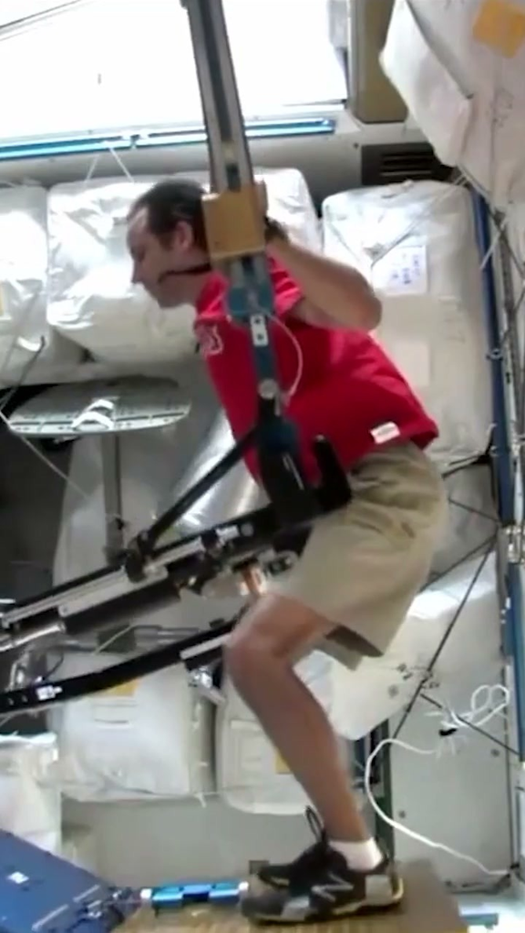

clips/microgravity.mp4  
720x1280, 13.9 s, 3.1 MB  
Cover frame: 12.2 s

### TikTok @example.orbit

Tue 12 Jan 2027, 18:00 EST (in 61 days 12 h)

Why astronauts work out for hours every day Without gravity, bone and muscle waste away. The treadmill, the bike and the weights are how they keep both. Footage: NASA. #astronaut #spacestation #nasa

198/2200 characters, 3 hashtags

seen by everyonecomments onduets offstitches offno promotion labelno AI label

Cover: covers/microgravity.jpg is sent with the post (the frame at 12.2 s)

By posting, you agree to TikTok's Music Usage Confirmation.

### Reels @example.orbit Instagram Reels

Tue 12 Jan 2027, 18:00 EST (in 61 days 12 h)

Astronauts on the space station exercise for hours every day. In microgravity the body stops carrying its own weight, and bone and muscle are lost. A treadmill with a harness, a bike and a resistance machine are how crews hold on to both until they are back on Earth. Footage: NASA. #spacestation #nasa #microgravity #astronaut

Reelno AI labelno paid partnership label

Cover: covers/microgravity.jpg is sent with the post (the frame at 12.2 s)

### Shorts YouTube Shorts

Tue 12 Jan 2027, 18:00 EST (in 61 days 12 h) by hand

Why astronauts exercise for hours every day in space

In microgravity the body stops carrying its own weight, so bone and muscle waste away unless crews train every day. Footage: NASA, "What Are the Dangers of Going to Space? We Asked a NASA Expert". #astronaut #spacestation #nasa

title 52/100 characters, description 227/5000 bytes

publicnot made for kidsScience & Technologytags: space station, ISS, microgravity, astronaut exercise, NASA, bone loss

Cover: pick the frame at 12.2 s in the YouTube app after uploading

## By hand

These accounts aren't connected, so each has a page with its text and steps:

- `by-hand/microgravity/shorts.md`

## Files to upload

- `clips/microgravity.mp4 (3.1 MB)`
- `covers/microgravity.jpg (0.1 MB)`